# YOLOv3 for License Plate Detection

The implementation is heavily based on [this repository](https://github.com/aladdinpersson/Machine-Learning-Collection/tree/master/ML/Pytorch/object_detection/YOLOv3)

Some important variables. Change them to change the model's configuration

```python
# path settings
DATA_PATH = "./dataset"  # where training, validaiton, and test samples are stored
LOG_PATH = "./log"  # directory to save checkpoints and tensorboard events
MODEL_NAME = "yolov3_plate_detection"  # name of the model
# model settings
IMG_SZ = 416  # image size
SEED = 0  # random seed
CONF_THRES = 0.4  # threshold for the predicted confidence score
AP_IOU_THRES = 0.5  # IOU threshold when computing average precision
NMS_IOU_THRES = 0.4  # IOU threshold for non-maximum suppresion
LABEL_IOU_THRES = 0.5  # IOU threshold for loading the labels
# optimization settings
DEVICE = "cuda"  # training/evaluation device
NUM_WORKERS = 1  # number of processes for data loading
BATCH_SZ = 16  # batch size
LR = 1e-4  # learning rate
SCHEDULER_STEP = 200  # frequency in epochs for scheduler update
SCHEDULER_RATE = 0.1  # factor to update the learning rate
WEIGHT_DECAY = 5e-4  # regularization term
NUM_EPOCHS = 400  # number of training epochs
# loss settings
LAMBDA_BOX = 10  # weight for bounding box loss
LAMBDA_OBJ = 1  # weight for object loss
LAMBDA_NOOBJ = 10  # weight for no object loss
# logging settings
LOG_FREQ = 1000  # frequency in epochs for logging the tensorboard events
SAVE_FREQ = 200  # frequency in epochs for saving a checkpoint
```

**Helper functions**

- Calculate IOU
- Convert grid cells to bounding box representations
- Non maximum suppression (an important step in YOLOv3) for removing redundant bounding box predictions
- Obtain predictions
- Calculate average precision

```python
import time
import torch

from collections import Counter


def iou_width_height(boxes1, boxes2):
    """
    Parameters:
        boxes1 (tensor): width and height of the first bounding boxes
        boxes2 (tensor): width and height of the second bounding boxes
    Returns:
        tensor: Intersection over union of the corresponding boxes
    """
    intersection = torch.min(boxes1[..., 0], boxes2[..., 0]) * torch.min(
        boxes1[..., 1], boxes2[..., 1]
    )
    union = (
            boxes1[..., 0] * boxes1[..., 1] + boxes2[..., 0] * boxes2[..., 1] - intersection
    )
    return intersection / union


def intersection_over_union(boxes_preds, boxes_labels, box_format="midpoint"):
    """
    Video explanation of this function:
    https://youtu.be/XXYG5ZWtjj0

    This function calculates intersection over union (iou) given pred boxes
    and target boxes.

    Parameters:
        boxes_preds (tensor): Predictions of Bounding Boxes (BATCH_SIZE, 4)
        boxes_labels (tensor): Correct labels of Bounding Boxes (BATCH_SIZE, 4)
        box_format (str): midpoint/corners, if boxes (x,y,w,h) or (x1,y1,x2,y2)

    Returns:
        tensor: Intersection over union for all examples
    """

    if box_format == "midpoint":
        box1_x1 = boxes_preds[..., 0:1] - boxes_preds[..., 2:3] / 2
        box1_y1 = boxes_preds[..., 1:2] - boxes_preds[..., 3:4] / 2
        box1_x2 = boxes_preds[..., 0:1] + boxes_preds[..., 2:3] / 2
        box1_y2 = boxes_preds[..., 1:2] + boxes_preds[..., 3:4] / 2
        box2_x1 = boxes_labels[..., 0:1] - boxes_labels[..., 2:3] / 2
        box2_y1 = boxes_labels[..., 1:2] - boxes_labels[..., 3:4] / 2
        box2_x2 = boxes_labels[..., 0:1] + boxes_labels[..., 2:3] / 2
        box2_y2 = boxes_labels[..., 1:2] + boxes_labels[..., 3:4] / 2

    elif box_format == "corners":
        box1_x1 = boxes_preds[..., 0:1]
        box1_y1 = boxes_preds[..., 1:2]
        box1_x2 = boxes_preds[..., 2:3]
        box1_y2 = boxes_preds[..., 3:4]
        box2_x1 = boxes_labels[..., 0:1]
        box2_y1 = boxes_labels[..., 1:2]
        box2_x2 = boxes_labels[..., 2:3]
        box2_y2 = boxes_labels[..., 3:4]

    else:
        print("Invalid box format")
        raise RuntimeError

    x1 = torch.max(box1_x1, box2_x1)
    y1 = torch.max(box1_y1, box2_y1)
    x2 = torch.min(box1_x2, box2_x2)
    y2 = torch.min(box1_y2, box2_y2)

    intersection = (x2 - x1).clamp(0) * (y2 - y1).clamp(0)
    box1_area = abs((box1_x2 - box1_x1) * (box1_y2 - box1_y1))
    box2_area = abs((box2_x2 - box2_x1) * (box2_y2 - box2_y1))

    return intersection / (box1_area + box2_area - intersection + 1e-6)


def cells_to_bboxes(predictions, anchors, S, is_preds=True):
    """
    convert the predicted grid cells from the model to bounding box format
    INPUT:
    predictions: tensor of size (N, 3, S, S, 5), N-batch size, S-feature size
    anchors: the anchors used for the predictions
    S: the number of cells the image is divided in on the width (and height)
    is_preds: whether the input is predictions or the true bounding boxes
    OUTPUT:
    converted_bboxes: the converted boxes of sizes (N, num_anchors * S * S, 5) with class index,
                      object score, bounding box coordinates
    """
    BATCH_SIZE = predictions.shape[0]
    num_anchors = len(anchors)
    box_predictions = predictions[..., 1:5]
    if is_preds:
        anchors = anchors.reshape(1, len(anchors), 1, 1, 2)
        box_predictions[..., 0:2] = torch.sigmoid(box_predictions[..., 0:2])  # for box coordinate
        box_predictions[..., 2:] = torch.exp(box_predictions[..., 2:]) * anchors  # for box size
        scores = torch.sigmoid(predictions[..., 0:1])  # confidence score
    else:
        scores = predictions[..., 0:1]

    cell_indices = (torch.arange(S).repeat(predictions.shape[0], 3, S, 1).unsqueeze(-1).to(predictions.device))
    x = 1 / S * (box_predictions[..., 0:1] + cell_indices)
    y = 1 / S * (box_predictions[..., 1:2] + cell_indices.permute(0, 1, 3, 2, 4))
    w_h = 1 / S * box_predictions[..., 2:4]
    converted_bboxes = torch.cat((scores, x, y, w_h), dim=-1).reshape(BATCH_SIZE, num_anchors * S * S, 5)
    return converted_bboxes.tolist()


def non_max_suppression(bboxes, iou_threshold, threshold, box_format="corners"):
    """
    Video explanation of this function:
    https://youtu.be/YDkjWEN8jNA

    Does Non Max Suppression given bboxes

    Parameters:
        bboxes (list): list of lists containing all bboxes with each bboxes
        specified as [class_pred, prob_score, x1, y1, x2, y2]
        iou_threshold (float): threshold where predicted bboxes is correct
        threshold (float): threshold to remove predicted bboxes (independent of IoU)
        box_format (str): "midpoint" or "corners" used to specify bboxes

    Returns:
        list: bboxes after performing NMS given a specific IoU threshold
    """

    assert type(bboxes) == list

    # only keep bounding boxes with a confidence score higher than the threshold
    bboxes = [box for box in bboxes if box[0] > threshold]
    # fort bboxes according to the confidence
    bboxes = sorted(bboxes, key=lambda x: x[0], reverse=True)
    bboxes_after_nms = []

    while bboxes:
        chosen_box = bboxes.pop(0)
        # only keep bounding boxes that do not overlap too much
        bboxes = [box for box in bboxes if intersection_over_union(torch.tensor(chosen_box[1:]), torch.tensor(box[1:]),
                                                                   box_format=box_format) < iou_threshold]

        bboxes_after_nms.append(chosen_box)

    return bboxes_after_nms


def get_eval_pred(loader, model, conf_thres, nms_iou_thres, norm_anchors, box_format="midpoint", device="cuda"):
    # evaluate a model and get all predictions
    model.eval()
    total_time = 0
    sample_idx = 0
    all_pred_boxes = []
    all_true_boxes = []
    tot_noobj, correct_noobj = 0, 0
    tot_obj, correct_obj = 0, 0

    for batch_idx, (imgs, labels) in enumerate(loader):
        imgs = imgs.to(device)
        with torch.no_grad():
            start_time = time.time()
            predictions = model(imgs)
            total_time = total_time + (time.time() - start_time)

        for i in range(3):
            labels[i] = labels[i].to(device)
            obj = labels[i][..., 0] == 1
            noobj = labels[i][..., 0] == 0

            obj_preds = torch.sigmoid(predictions[i][..., 0]) > conf_thres
            # grid cells that have been correctly classified to have an object
            correct_obj += torch.sum(obj_preds[obj] == labels[i][..., 0][obj])
            tot_obj += torch.sum(obj)
            # grid cells that have been correctly classified to not have an object
            correct_noobj += torch.sum(obj_preds[noobj] == labels[i][..., 0][noobj])
            tot_noobj += torch.sum(noobj)

        batch_size = imgs.shape[0]
        bboxes = [[] for _ in range(batch_size)]
        for i in range(3):
            S = predictions[i].shape[2]
            anchor = torch.tensor([*norm_anchors[i]]).to(device) * S
            boxes_scale_i = cells_to_bboxes(predictions[i], anchor, S=S, is_preds=True)
            for idx, (box) in enumerate(boxes_scale_i):
                bboxes[idx] += box

        # we just want one bbox for each label, not one for each scale
        true_bboxes = cells_to_bboxes(labels[2], anchor, S=S, is_preds=False)

        for idx in range(batch_size):
            nms_boxes = non_max_suppression(
                bboxes[idx],
                iou_threshold=nms_iou_thres,
                threshold=conf_thres,
                box_format=box_format,
            )

            # append the sample id with each bounding boxes
            for nms_box in nms_boxes:
                all_pred_boxes.append([sample_idx] + nms_box)

            for box in true_bboxes[idx]:
                if box[0] > conf_thres:
                    all_true_boxes.append([sample_idx] + box)
            sample_idx += 1
    return all_pred_boxes, all_true_boxes, tot_noobj, correct_noobj, tot_obj, correct_obj, total_time


def average_precision(pred_boxes, true_boxes, iou_threshold=0.5, box_format="midpoint"):
    """
    Video explanation of this function:
    https://youtu.be/FppOzcDvaDI

    This function calculates mean average precision (mAP)

    Parameters:
        pred_boxes (list): list of lists containing all bboxes with each bboxes
        specified as [train_idx, class_prediction, prob_score, x1, y1, x2, y2]
        true_boxes (list): Similar as pred_boxes except all the correct ones
        iou_threshold (float): threshold where predicted bboxes is correct
        box_format (str): "midpoint" or "corners" used to specify bboxes
        num_classes (int): number of classes

    Returns:
        float: mAP value across all classes given a specific IoU threshold
    """

    # used for numerical stability later on
    epsilon = 1e-6

    detections = pred_boxes
    ground_truths = true_boxes
    gt_box = len(true_boxes)

    # find the amount of bboxes for each training example
    # Counter here finds how many ground truth bboxes we get
    # for each training example, so let's say img 0 has 3,
    # img 1 has 5 then we will obtain a dictionary with:
    # amount_bboxes = {0:3, 1:5}
    amount_bboxes = Counter([gt[0] for gt in ground_truths])

    # We then go through each key, val in this dictionary
    # and convert to the following (w.r.t same example):
    # ammount_bboxes = {0:torch.tensor[0,0,0], 1:torch.tensor[0,0,0,0,0]}
    for key, val in amount_bboxes.items():
        amount_bboxes[key] = torch.zeros(val)

    # sort by box probabilities which is index 2
    detections.sort(key=lambda x: x[1], reverse=True)
    TP = torch.zeros((len(detections)))
    FP = torch.zeros((len(detections)))
    total_true_bboxes = len(ground_truths)

    for detection_idx, detection in enumerate(detections):
        # Only take out the ground_truths that have the same
        # training idx as detection
        ground_truth_img = [
            bbox for bbox in ground_truths if bbox[0] == detection[0]
        ]
        best_iou = 0

        for idx, gt in enumerate(ground_truth_img):
            iou = intersection_over_union(
                torch.tensor(detection[2:]),
                torch.tensor(gt[2:]),
                box_format=box_format,
            )

            if iou > best_iou:
                best_iou = iou
                best_gt_idx = idx

        if best_iou > iou_threshold:
            # only detect ground truth detection once
            if amount_bboxes[detection[0]][best_gt_idx] == 0:
                # true positive and add this bounding box to seen
                TP[detection_idx] = 1
                amount_bboxes[detection[0]][best_gt_idx] = 1
            else:
                FP[detection_idx] = 1

        # if IOU is lower then the detection is a false positive
        else:
            FP[detection_idx] = 1

    TP_cumsum = torch.cumsum(TP, dim=0)
    FP_cumsum = torch.cumsum(FP, dim=0)
    tp_box = torch.sum(TP)
    fp_box = torch.sum(FP)
    recalls = TP_cumsum / (total_true_bboxes + epsilon)
    precisions = TP_cumsum / (TP_cumsum + FP_cumsum + epsilon)
    precisions = torch.cat((torch.tensor([1]), precisions))
    recalls = torch.cat((torch.tensor([0]), recalls))
    # torch.trapz for numerical integration
    average_precisions = torch.trapz(precisions, recalls)

    return average_precisions, gt_box, tp_box, fp_box
```

**Dataset class**

The dataset can be downloaded from [here](https://drive.google.com/file/d/1Qw21wZUm64NyU8qQvwiA1Y6jVTR1yjRz/view?usp=share_link). The files and dataset should be organized in the following way:

```
./
|-- YOLOv3_plate_detection.ipynb
|-- dataset/
|   |-- archive/
|   |-- License Plates.v3-original-license-plates.voc/
|   |-- test.txt
|   |-- train.txt
|   |-- train_val.txt
|   |-- val.txt
```

The dataset class can load data from the training set, validation set, test set and preprocess data accordingly. You can also let this class return only a few samples for sanity check.

```python
import os
import cv2
import numpy as np
import albumentations as A
import xml.etree.ElementTree as ET

from PIL import Image
from torch.utils.data import Dataset
from albumentations.pytorch import ToTensorV2


class LicensePlateDataset(Dataset):
    def __init__(self, data_path, dataset_status, norm_anchors, img_size, down_sz, ignore_iou_thres, sanity=False):
        """
        Dataset class

        Parameters:
            data_path: path to the dataset
            dataset_status: idicates which dataset split to load, 0->train.txt, 1->val.txt, 2->text.txt, 3->train_val.txt
            norm_anchors: normalized size for anchor boxes
            img_size: size of the output image
            down_sz: downampling factor at each stage of the model
            ignore_iou_thres: iou threshold to ignore overlapping bounding boxes
            sanity: if set to True, the dataset class only returns four images to perform sanity check
        """
        super(LicensePlateDataset, self).__init__()
        self.data_path = data_path
        self.ignore_iou_thres = ignore_iou_thres
        self.feat_sz = [img_size // down_sz[0], img_size // down_sz[1], img_size // down_sz[2]]
        self.norm_anchors = torch.tensor(norm_anchors[0] + norm_anchors[1] + norm_anchors[2])
        self.num_anchors = self.norm_anchors.shape[0]
        self.num_anchors_per_scale = self.num_anchors // len(norm_anchors)

        if dataset_status == 0 or dataset_status == 3:
            # 0 -> training, 1 -> validation, 2 -> testing, 3 -> training + validation
            if dataset_status == 0:
                with open(os.path.join(data_path, "train.txt")) as f:
                    self.data_list = f.readlines()
            else:
                with open(os.path.join(data_path, "train_val.txt")) as f:
                    self.data_list = f.readlines()
            if sanity:
                # only perform basic preprocessing when we do sanity check
                self.transforms = A.Compose(
                    [A.LongestMaxSize(max_size=img_size),
                     A.PadIfNeeded(min_height=img_size, min_width=img_size, border_mode=cv2.BORDER_CONSTANT),
                     A.Normalize(),
                     ToTensorV2()],
                    bbox_params=A.BboxParams(format='yolo', min_visibility=0.4, label_fields=[])
                )
            else:
                scale = 1.1
                # data augmentation when traning only the full traning set or train+val set
                self.transforms = A.Compose(
                    [A.LongestMaxSize(max_size=int(img_size * scale)),
                     A.PadIfNeeded(min_height=int(img_size * scale), min_width=int(img_size * scale),
                                   border_mode=cv2.BORDER_CONSTANT),
                     A.RandomCrop(width=img_size, height=img_size),
                     A.ColorJitter(brightness=0.6, contrast=0.6, saturation=0.6, hue=0.6, p=0.4),
                     A.OneOf([A.ShiftScaleRotate(rotate_limit=20, p=0.5, border_mode=cv2.BORDER_CONSTANT),
                              A.Affine(shear=15, p=0.5, mode=cv2.BORDER_CONSTANT), ], p=1.0),
                     A.Blur(p=0.1),
                     A.CLAHE(p=0.1),
                     A.Posterize(p=0.1),
                     A.ToGray(p=0.1),
                     A.ChannelShuffle(p=0.05),
                     A.Normalize(), ToTensorV2()],
                    bbox_params=A.BboxParams(format='yolo', min_visibility=0.4, label_fields=[])
                )
        elif dataset_status == 1:
            with open(os.path.join(data_path, "val.txt")) as f:
                self.data_list = f.readlines()
            # basic preprocessing for validation
            self.transforms = A.Compose(
                [A.LongestMaxSize(max_size=img_size),
                 A.PadIfNeeded(min_height=img_size, min_width=img_size, border_mode=cv2.BORDER_CONSTANT),
                 A.Normalize(), ToTensorV2()],
                bbox_params=A.BboxParams(format='yolo', min_visibility=0.4, label_fields=[])
            )
        else:
            with open(os.path.join(data_path, "test.txt")) as f:
                self.data_list = f.readlines()
            # basic preprocessing for testing
            self.transforms = A.Compose(
                [A.LongestMaxSize(max_size=img_size),
                 A.PadIfNeeded(min_height=img_size, min_width=img_size, border_mode=cv2.BORDER_CONSTANT),
                 A.Normalize(), ToTensorV2()],
                bbox_params=A.BboxParams(format='yolo', min_visibility=0.4, label_fields=[])
            )

        self.data_list = [data.strip("\n") for data in self.data_list]
        self.data_list.sort()
        # only keep the first four images for sanity check
        if sanity:
            self.data_list = self.data_list[0:4]

    def __len__(self):
        return len(self.data_list)

    def __getitem__(self, item):
        entry = self.data_list[item]
        img_file, annotation_file = entry.split(", ")

        # read the image
        image = np.array(Image.open(img_file).convert("RGB"))
        img_h, img_w, _ = np.shape(image)
        # process the xml file to get ground truth information
        annotation = ET.parse(annotation_file)
        annotation_root = annotation.getroot()
        objs = annotation_root.findall("object")
        bboxes = []
        for obj in objs:
            obj_name = obj.find("name")
            if obj_name.text == "licence" or obj_name.text == "license-plate":
                # find bounding box information
                bndbox = obj.find("bndbox")
                # in xml, the x and y coordinates of two corners of the bounding box are given
                # transform these to the x y coordinates of the box center and height and width
                xmin = np.maximum(int(bndbox.find("xmin").text) - 1, 0)
                ymin = np.maximum(int(bndbox.find("ymin").text) - 1, 0)
                xmax = int(bndbox.find("xmax").text) - 1
                ymax = int(bndbox.find("ymax").text) - 1
                x_center = (xmax + xmin) / 2
                y_center = (ymax + ymin) / 2
                width = xmax - xmin
                height = ymax - ymin
                bbox = np.array(([x_center / img_w, y_center / img_h, width / img_w, height / img_h]))
                bboxes.append(bbox)

        if len(bboxes) == 0:
            # if an image does not have bounding boxes, raise error
            print("No bounding boxes found for %s" % img_file)
            raise RuntimeError

        # pre-processing/data augmentation
        augmentations = self.transforms(image=image, bboxes=bboxes)
        image = augmentations["image"]
        bboxes = augmentations["bboxes"]

        # Below assumes 3 scale predictions (as paper) and same num of anchors per scale
        # targets store the bounding box information at different scale with respect to different anchor boxes
        targets = [torch.zeros((self.num_anchors // 3, sz, sz, 5)) for sz in self.feat_sz]
        for box in bboxes:
            # calculate iou between the bouding box and each pre-defined anchor boxes
            # there are three anchor boxes for each scale and three scales in total
            iou_anchors = iou_width_height(torch.tensor(box[2:4]), self.norm_anchors)
            anchor_indices = iou_anchors.argsort(descending=True, dim=0)
            x, y, width, height = box
            has_anchor = [False] * 3  # each scale should have one anchor
            # organize the ground truth information into the format of grid cells
            for anchor_idx in anchor_indices:
                scale_idx = torch.div(anchor_idx, self.num_anchors_per_scale, rounding_mode="floor")
                anchor_on_scale = anchor_idx % self.num_anchors_per_scale
                sz = self.feat_sz[scale_idx]
                i, j = int(sz * y), int(sz * x)  # which cell
                anchor_taken = targets[scale_idx][anchor_on_scale, i, j, 0]
                if not anchor_taken and not has_anchor[scale_idx]:
                    targets[scale_idx][anchor_on_scale, i, j, 0] = 1
                    x_cell, y_cell = sz * x - j, sz * y - i  # both between [0,1]
                    # can be greater than 1 since it's relative to cell
                    width_cell, height_cell = (width * sz, height * sz,)
                    box_coordinates = torch.tensor([x_cell, y_cell, width_cell, height_cell])
                    targets[scale_idx][anchor_on_scale, i, j, 1:5] = box_coordinates
                    has_anchor[scale_idx] = True
                elif not anchor_taken and iou_anchors[anchor_idx] > self.ignore_iou_thres:
                    targets[scale_idx][anchor_on_scale, i, j, 0] = -1  # ignore prediction
        return image, tuple(targets)
```

**YOLO model**

```python
import torch.nn as nn


"""
Information about architecture config:
Tuple is structured by (filters, kernel_size, stride)
Every conv is a same convolution.
List is structured by "B" indicating a residual block followed by the number of repeats
"S" is for scale prediction block and computing the yolo loss
"U" is for upsampling the feature map and concatenating with a previous layer
"""
config = [
    (32, 3, 1),
    (64, 3, 2),
    ["B", 1],
    (128, 3, 2),
    ["B", 2],
    (256, 3, 2),
    ["B", 8],
    (512, 3, 2),
    ["B", 8],
    (1024, 3, 2),
    ["B", 4],  # To this point is Darknet-53
    (512, 1, 1),
    (1024, 3, 1),
    "S",
    (256, 1, 1),
    "U",
    (256, 1, 1),
    (512, 3, 1),
    "S",
    (128, 1, 1),
    "U",
    (128, 1, 1),
    (256, 3, 1),
    "S",
]


# building blocks for building the model
# conv + batch norm + leaky relu
class CNNBlock(nn.Module):
    def __init__(self, in_channels, out_channels, bn_act=True, **kwargs):
        super().__init__()
        self.conv = nn.Conv2d(in_channels, out_channels, bias=not bn_act, **kwargs)
        self.bn = nn.BatchNorm2d(out_channels)
        self.leaky = nn.LeakyReLU(0.1)
        self.use_bn_act = bn_act

    def forward(self, x):
        if self.use_bn_act:
            return self.leaky(self.bn(self.conv(x)))
        else:
            return self.conv(x)


# residual block
class ResidualBlock(nn.Module):
    def __init__(self, channels, use_residual=True, num_repeats=1):
        super().__init__()
        self.layers = nn.ModuleList()
        for repeat in range(num_repeats):
            self.layers += [
                nn.Sequential(
                    CNNBlock(channels, channels // 2, kernel_size=1),
                    CNNBlock(channels // 2, channels, kernel_size=3, padding=1),
                )
            ]

        self.use_residual = use_residual
        self.num_repeats = num_repeats

    def forward(self, x):
        for layer in self.layers:
            if self.use_residual:
                x = x + layer(x)
            else:
                x = layer(x)

        return x


# layers for making predictions
class ScalePrediction(nn.Module):
    def __init__(self, in_channels):
        super().__init__()
        self.pred = nn.Sequential(
            CNNBlock(in_channels, 2 * in_channels, kernel_size=3, padding=1),
            CNNBlock(
                2 * in_channels, 5 * 3, bn_act=False, kernel_size=1
            ),
        )

    def forward(self, x):
        return (
            self.pred(x)
                .reshape(x.shape[0], 3, 5, x.shape[2], x.shape[3])
                .permute(0, 1, 3, 4, 2)
        )


class YOLOv3(nn.Module):
    def __init__(self, in_channels=3):
        super().__init__()
        self.in_channels = in_channels
        self.layers = self._create_conv_layers()

    def forward(self, x):
        outputs = []  # for each scale
        route_connections = []
        for layer in self.layers:
            if isinstance(layer, ScalePrediction):
                outputs.append(layer(x))
                continue

            x = layer(x)

            if isinstance(layer, ResidualBlock) and layer.num_repeats == 8:
                route_connections.append(x)

            elif isinstance(layer, nn.Upsample):
                x = torch.cat([x, route_connections[-1]], dim=1)
                route_connections.pop()

        return outputs

    def _create_conv_layers(self):
        layers = nn.ModuleList()
        in_channels = self.in_channels

        # use config to build a model
        for module in config:
            if isinstance(module, tuple):
                out_channels, kernel_size, stride = module
                layers.append(
                    CNNBlock(
                        in_channels,
                        out_channels,
                        kernel_size=kernel_size,
                        stride=stride,
                        padding=1 if kernel_size == 3 else 0,
                    )
                )
                in_channels = out_channels

            elif isinstance(module, list):
                num_repeats = module[1]
                layers.append(ResidualBlock(in_channels, num_repeats=num_repeats, ))

            elif isinstance(module, str):
                if module == "S":
                    layers += [
                        ResidualBlock(in_channels, use_residual=False, num_repeats=1),
                        CNNBlock(in_channels, in_channels // 2, kernel_size=1),
                        ScalePrediction(in_channels // 2),
                    ]
                    in_channels = in_channels // 2

                elif module == "U":
                    layers.append(nn.Upsample(scale_factor=2), )
                    in_channels = in_channels * 3

        return layers

    @staticmethod
    def _weight_init(m):
        """
        Initialize a layer's weight according to normal distribution and its bias terms with zeros
        :param m: a layer in tensor form
        :return: None
        """
        if isinstance(m, nn.Conv2d):
            torch.nn.init.normal_(m.weight, 0, 0.01)
            if m.bias is not None:
                torch.nn.init.zeros_(m.bias)

    def init_model(self):
        self.layers.apply(self._weight_init)
        print("Model weights have been initialized randomly")
```

**Training Loss**

The YOLO training loss has multiple components. Here, we only use three components. The fourth one (cross entrypy loss for multi-class classification) is discarded since it is unnecessary here. The components we consider are

- Object loss to the help the model predict an object
- No object loss to help the model suppress detections at area with no objects
- Boudning box loss to help the model predict the correct bounding box geometry

```python
class YoloLoss(nn.Module):
    def __init__(self, lambda_box=10, lambda_obj=1, lambda_noobj=10):
        super(YoloLoss, self).__init__()
        self.mse = nn.MSELoss()  # for object and bounding box losses
        self.bce = nn.BCEWithLogitsLoss()  # for no object loss
        self.sigmoid = nn.Sigmoid()  # for converting the predictions

        # Constants signifying how much to pay for each respective part of the loss
        self.lambda_noobj = lambda_noobj  # weight for the no object loss
        self.lambda_obj = lambda_obj  # weight for the object loss
        self.lambda_box = lambda_box  # weight for the bounding box loss

    def forward(self, predictions, target, anchors):
        # Check where obj and noobj (we ignore if target == -1)
        obj = target[..., 0] == 1  # apply object loss to these celss
        noobj = target[..., 0] == 0  # apply no object loss to these cells

        # ======================= #
        #   FOR NO OBJECT LOSS    #
        # ======================= #

        no_object_loss = self.bce(
            (predictions[..., 0:1][noobj]), (target[..., 0:1][noobj]),
        )

        # ==================== #
        #   FOR OBJECT LOSS    #
        # ==================== #

        anchors = anchors.reshape(1, 3, 1, 1, 2)
        # predictions[..., 1:3] bounding box location, predictions[..., 3:5] bounding box size
        box_preds = torch.cat([self.sigmoid(predictions[..., 1:3]), torch.exp(predictions[..., 3:5]) * anchors], dim=-1)
        ious = intersection_over_union(box_preds[obj], target[..., 1:5][obj]).detach()
        # predicions[..., 0:1] and target[..., 0:1] are the confidence score for an object
        object_loss = self.mse(self.sigmoid(predictions[..., 0:1][obj]), ious * target[..., 0:1][obj])

        # ======================== #
        #   FOR BOX COORDINATES    #
        # ======================== #

        predictions[..., 1:3] = self.sigmoid(predictions[..., 1:3])  # x,y coordinates
        target[..., 3:5] = torch.log((1e-16 + target[..., 3:5] / anchors))  # width, height coordinates
        box_loss = self.mse(predictions[..., 1:5][obj], target[..., 1:5][obj])

        return (
                self.lambda_box * box_loss
                + self.lambda_obj * object_loss
                + self.lambda_noobj * no_object_loss
        )
```

**A trainer class to train the model**

```python
import torch.optim as optim
import torchvision.transforms as transforms
from torch.utils.data import DataLoader
from tensorboardX import SummaryWriter  # intermediate results are saved in a tensorboard event


class YOLOv3Trainer:
    def __init__(self):
        torch.manual_seed(SEED)
        self.scales = [32, 16, 8]  # downsampling factors at each scale
        self.norm_anchors = []
        # predefined anchor box size
        # according to the original code
        anchors = [
            [(116, 90), (156, 198), (373, 326)],
            [(30, 61), (62, 45), (59, 119)],
            [(10, 13), (16, 30), (33, 23)]
        ]
        # normalize the anchor box size by the image size
        for scale in range(len(anchors)):
            norm_anchors_at_scale = []
            for anchor in range(len(anchors[scale])):
                norm_anchor = [anchors[scale][anchor][0] / IMG_SZ,
                               anchors[scale][anchor][1] / IMG_SZ]
                norm_anchors_at_scale.append(norm_anchor)
            self.norm_anchors.append(norm_anchors_at_scale)
        # anchor box size in each scale
        self.scaled_anchors = (torch.tensor(self.norm_anchors) * torch.tensor(
            [IMG_SZ // self.scales[0], IMG_SZ // self.scales[1],
             IMG_SZ // self.scales[2]]).unsqueeze(1).unsqueeze(1).repeat(1, 3, 2)).to(DEVICE)

        # define model, optimizer, scheduler, and training loss
        self.model = YOLOv3()
        self.model = self.model.to(DEVICE)
        self.model.init_model()
        self.optimizer = optim.Adam(self.model.parameters(), lr=LR, weight_decay=WEIGHT_DECAY)
        self.scheduler = optim.lr_scheduler.StepLR(self.optimizer, SCHEDULER_STEP, SCHEDULER_RATE)
        self.loss = YoloLoss(LAMBDA_BOX, LAMBDA_OBJ, LAMBDA_NOOBJ)

        # define dataset
        sanity = False
        self.train_dataset = LicensePlateDataset(DATA_PATH, 0, self.norm_anchors, IMG_SZ, self.scales,
                                                 LABEL_IOU_THRES, sanity=sanity)
        self.val_dataset = LicensePlateDataset(DATA_PATH, 1, self.norm_anchors, IMG_SZ, self.scales,
                                               LABEL_IOU_THRES, sanity=sanity)
        self.train_loader = DataLoader(self.train_dataset, batch_size=BATCH_SZ, num_workers=NUM_WORKERS,
                                       pin_memory=True, shuffle=True, drop_last=False)
        self.val_loader = DataLoader(self.val_dataset, batch_size=BATCH_SZ, num_workers=NUM_WORKERS,
                                     pin_memory=True, shuffle=False, drop_last=False)
        self.val_iter = iter(self.val_loader)

        # path for logging the model checkpoints and tensorboard events
        self.log_path = os.path.join(LOG_PATH, MODEL_NAME)
        # writer for logging the tensorboard events
        self.train_writer = SummaryWriter(os.path.join(self.log_path, "train"))
        self.val_writer = SummaryWriter(os.path.join(self.log_path, "val"))

        # revert the image normalizaiton by ImageNet stat for better plotting
        self.inv_normalize = transforms.Normalize(
            mean=[-0.485 / 0.229, -0.456 / 0.224, -0.406 / 0.225],
            std=[1 / 0.229, 1 / 0.224, 1 / 0.225])

        self.current_epoch = 0
        self.current_step = 0

        print("Begin training %s" % MODEL_NAME)
        print("-------------Logging Info-------------")
        print("Checkpoints and log saved in: %s" % LOG_PATH)
        print("Checkpoint save frequency: %d" % SAVE_FREQ)
        print("Mini-batch is evaluated at frequency: %d" % LOG_FREQ)
        print("-------------Model Info-------------")
        print("Image size: %d" % IMG_SZ)
        print("Confidence threshold: %.2f" % CONF_THRES)
        print("IOU threshold for generating labels: %.2f" % LABEL_IOU_THRES)
        print("IOU threshold for NMS: %.2f" % NMS_IOU_THRES)
        print("IOU threshold for AP: %.2f" % AP_IOU_THRES)
        print("-------------Optimization Info-------------")
        print("Training device: %s" % DEVICE)
        print("Training set identification: %d" % 0)
        print("Number of training images: %d" % len(self.train_dataset))
        print("Number of validation images: %d" % len(self.val_dataset))
        print("Batch size: %d" % BATCH_SZ)
        print("Number of epochs: %d" % NUM_EPOCHS)
        print("Initial learning rate: %.5f" % LR)
        print("Scheduler step: %d" % SCHEDULER_STEP)
        print("Scheduler rate: %.2f" % SCHEDULER_RATE)
        print("-------------Loss Info-------------")
        print("Lambda box: %.2f" % LAMBDA_BOX)
        print("Lambda obj: %.2f" % LAMBDA_OBJ)
        print("Lambda noobj: %.2f" % LAMBDA_NOOBJ)

    def train(self):
        print("---------------Start training---------------")
        for self.current_epoch in range(NUM_EPOCHS):
            print("Training epoch %d" % (self.current_epoch + 1))
            self.train_epoch()  # train each epoch
            self.scheduler.step()
            # save the checkpoint and evaluate on the full val set according to SAVE_FREQ
            if (self.current_epoch + 1) % SAVE_FREQ == 0:
                self.val()  # validaiton
                save_folder = os.path.join(self.log_path, "%d" % (self.current_epoch + 1))
                if not os.path.exists(save_folder):
                    os.makedirs(save_folder)
                checkpt_file = os.path.join(save_folder, "model.pth")
                optim_file = os.path.join(save_folder, "adam.pth")
                torch.save(self.model.state_dict(), checkpt_file)
                torch.save(self.optimizer.state_dict(), optim_file)

    def train_epoch(self):
        self.model.train()
        # iterate the whole training set for one epoch
        for batch_idx, (imgs, targets) in enumerate(self.train_loader):
            self.current_step += 1
            imgs = imgs.to(DEVICE)
            imgs = imgs
            target0, target1, target2 = (targets[0].to(DEVICE), targets[1].to(DEVICE), targets[2].to(DEVICE))
            predictions = self.model(imgs)
            loss = (self.loss(predictions[0], torch.clone(target0), self.scaled_anchors[0])
                    + self.loss(predictions[1], torch.clone(target1), self.scaled_anchors[1])
                    + self.loss(predictions[2], torch.clone(target2), self.scaled_anchors[2]))
            self.optimizer.zero_grad()
            loss.backward()
            self.optimizer.step()
```

```python
            # perform the following according to the predefined LOG_FREQ
            if self.current_step % LOG_FREQ == 0:
                print("Training Loss: %.4f" % loss)
                bboxes = []
                for i in range(3):
                    S = predictions[i].shape[2]
                    anchor = torch.tensor([*self.norm_anchors[i]]).to(DEVICE) * S
                    # convert the predictions from the train images from grid cells to bounding boxes
                    # only consider the first sample in the batch
                    boxes_scale_i = cells_to_bboxes(predictions[i][0:1, ...], anchor, S=S, is_preds=True)
                    bboxes += boxes_scale_i[0]
                # non maximum suppression to remove redundant bounding boxes
                pred_bboxes = non_max_suppression(bboxes, NMS_IOU_THRES, CONF_THRES, "midpoint")
                # convert ground truth grid cells to bounding boxes
                gt_bboxes = cells_to_bboxes(target0[0:1], self.scaled_anchors[0], IMG_SZ // self.scales[0],
                                            False)
                # create a predicted image with the original train image and the pred/gt bounding boxes
                img_bbox = self._create_pred_imgs(imgs[0], pred_bboxes, gt_bboxes[0])
                # log training loss and sample prediction in the tensorboard event
                self.train_writer.add_image("Sample_prediction", img_bbox, self.current_step)
                self.train_writer.add_scalar("Loss", loss, self.current_step)
                # validate the model with a mini batch from the val set
                self.val_mini_batch()

    def val(self):
        # validate on the entire val set
        all_pred_boxes, all_true_boxes, tot_noobj, correct_noobj, tot_obj, correct_obj, _ = get_eval_pred(
            self.val_loader, self.model, CONF_THRES, NMS_IOU_THRES, self.norm_anchors, "midpoint", DEVICE)
        # calculate accuracy
        self._cal_cls_obj_acc(tot_noobj, correct_noobj, tot_obj, correct_obj)
        # calculate average precision
        ap, _, _, _ = average_precision(all_pred_boxes, all_true_boxes, AP_IOU_THRES, "midpoint")
        print("AP: %.2f" % ap)
        # log the average precision to the tensorboard event
        self.val_writer.add_scalar("AP", ap, self.current_step)

    def _cal_cls_obj_acc(self, tot_noobj, correct_noobj, tot_obj, correct_obj):
        eps = 1e-16
        # accuracy for predicting cells with no objects
        noobj_acc = (correct_noobj / (tot_noobj + eps)) * 100
        # accuracy for predicting cells with objects
        obj_acc = (correct_obj / (tot_obj + eps)) * 100
        print("No obj accuracy: %.2f" % noobj_acc)
        print("Obj accuracy: %.2f" % obj_acc)
        # log these accuracies to the tensorboard event
        self.val_writer.add_scalar("No_Obj_Accuracy", noobj_acc, self.current_step)
        self.val_writer.add_scalar("Obj_Accuracy", obj_acc, self.current_step)

    def val_mini_batch(self):
        # validate the model on one mini batch
        self.model.eval()
        # load a mini batch
        try:
            imgs, targets = self.val_iter.next()
        except StopIteration:
            self.val_iter = iter(self.val_loader)
            imgs, targets = self.val_iter.next()

        imgs = imgs.to(DEVICE)
        target0, target1, target2 = (
            targets[0].to(DEVICE), targets[1].to(DEVICE), targets[2].to(DEVICE))
        with torch.no_grad():
            predictions = self.model(imgs)
            loss = (self.loss(predictions[0], torch.clone(target0), self.scaled_anchors[0])
                    + self.loss(predictions[1], torch.clone(target1), self.scaled_anchors[1])
                    + self.loss(predictions[2], torch.clone(target2), self.scaled_anchors[2]))
        bboxes = []
        for i in range(3):
            S = predictions[i].shape[2]
            anchor = torch.tensor([*self.norm_anchors[i]]).to(DEVICE) * S
            # convert grid cells to bounding boxes
            # only consider the first sample in the batch
            boxes_scale_i = cells_to_bboxes(predictions[i][0:1, ...], anchor, S=S, is_preds=True)
            bboxes += boxes_scale_i[0]
        # non maximum compression on the predicted bounding boxes
        pred_bboxes = non_max_suppression(bboxes, NMS_IOU_THRES, CONF_THRES, "midpoint")
        # convert ground truth grid cells to bounding boxes
        gt_bboxes = cells_to_bboxes(target0[0:1], self.scaled_anchors[0], IMG_SZ // self.scales[0], False)
        # create a predicted image with the original train image and the pred/gt bounding boxes
        img_bbox = self._create_pred_imgs(imgs[0], pred_bboxes, gt_bboxes[0])
        print("Validation loss: %.4f" % loss)
        # log the results in the tensorboard event
        self.val_writer.add_scalar("Loss", loss, self.current_step)
        self.val_writer.add_image("Sample_prediction", img_bbox, self.current_step)
        self.model.train()

    def _create_pred_imgs(self, img, pred_bbox, gt_bbox):
        # create an image with the original image and the bounding boxes
        img = self.inv_normalize(img)  # revert the ImageNet normalization
        img_bbox = img.squeeze().detach().cpu().numpy()
        img_bbox = 255 * np.transpose(img_bbox, (1, 2, 0))
        img_bbox = (img_bbox.astype(np.uint8)).copy()

        for i in range(len(gt_bbox)):
            # add the ground truth bounding boxes
            if gt_bbox[i][0] == 1:
                x1 = (gt_bbox[i][1] - gt_bbox[i][3] / 2) * IMG_SZ
                y1 = (gt_bbox[i][2] - gt_bbox[i][4] / 2) * IMG_SZ
                x2 = (gt_bbox[i][1] + gt_bbox[i][3] / 2) * IMG_SZ
                y2 = (gt_bbox[i][2] + gt_bbox[i][4] / 2) * IMG_SZ
                cv2.rectangle(img_bbox, (int(x1), int(y1)), (int(x2), int(y2)), (0, 0, 255), 2)
                cv2.putText(img_bbox, "GT", (int(x1), int(y1) - 5), cv2.FONT_HERSHEY_COMPLEX, 0.5, (0, 0, 255), 1)

        for i in range(len(pred_bbox)):
            # add the predicted bounding boxes
            x1 = (pred_bbox[i][1] - pred_bbox[i][3] / 2) * IMG_SZ
            y1 = (pred_bbox[i][2] - pred_bbox[i][4] / 2) * IMG_SZ
            x2 = (pred_bbox[i][1] + pred_bbox[i][3] / 2) * IMG_SZ
            y2 = (pred_bbox[i][2] + pred_bbox[i][4] / 2) * IMG_SZ
            cv2.rectangle(img_bbox, (int(x1), int(y1)), (int(x2), int(y2)), (255, 0, 0), 2)
            cv2.putText(img_bbox, "Pred", (int(x1), int(y1) - 5), cv2.FONT_HERSHEY_COMPLEX, 0.5, (255, 0, 0), 1)
```

```python
        img_bbox = img_bbox / 255.0
        img_bbox = np.transpose(img_bbox, (2, 0, 1))
        img_bbox = torch.tensor(img_bbox)
        return img_bbox
```

**Train the model**

```python
trainer = YOLOv3Trainer()
trainer.train()
```

```
Model weights have been initialized randomly
Begin training yolov3_plate_detection
-------------Logging Info-------------
Checkpoints and log saved in: ./log
Checkpoint save frequency: 200
Mini-batch is evaluated at frequency: 1000
-------------Model Info-------------
Image size: 416
Confidence threshold: 0.40
IOU threshold for generating labels: 0.50
IOU threshold for NMS: 0.40
IOU threshold for AP: 0.50
-------------Optimization Info-------------
Training device: cuda
Training set identification: 0
Number of training images: 678
Number of validation images: 70
Batch size: 16
Number of epochs: 400
Initial learning rate: 0.00010
Scheduler step: 200
Scheduler rate: 0.10
-------------Loss Info-------------
Lambda box: 10.00
Lambda obj: 1.00
Lambda noobj: 10.00
---------------Start training---------------
Training epoch 1
Training epoch 2
Training epoch 3
Training epoch 4
Training epoch 5
Training epoch 6
Training epoch 7
Training epoch 8
Training epoch 9
Training epoch 10
Training epoch 11
Training epoch 12
Training epoch 13
```

[output cut: 412 more lines]

```
Training epoch 391
Training epoch 392
Training epoch 393
Training epoch 394
Training epoch 395
Training epoch 396
Training Loss: 0.1865
Validation loss: 2.1110
Training epoch 397
Training epoch 398
Training epoch 399
Training epoch 400
No obj accuracy: 99.96
Obj accuracy: 80.95
AP: 0.81
```

**An evaluator class to evaluate the model on the validation/test set**

We use the test set here. Below are some variables for the evaluator.

```python
# path to the pretrained model
PRETRAINED_MODEL = "log/yolov3_plate_detection/400"  # directory of the saved checkpoint
NUM_IMG_TO_PLOT = 10  # number of images to plot at the end
EVAL_LOG_FREQ = 1  # logging frequency during evaluation
```

```python
class YOLOv3Evaluator:
    def __init__(self):
        self.scales = [32, 16, 8]
        self.norm_anchors = []
        anchors = [
            [(116, 90), (156, 198), (373, 326)],
            [(30, 61), (62, 45), (59, 119)],
            [(10, 13), (16, 30), (33, 23)]
        ]
        for scale in range(len(anchors)):
            norm_anchors_at_scale = []
            for anchor in range(len(anchors[scale])):  # 3 anchors in each scale
                norm_anchor = [anchors[scale][anchor][0] / IMG_SZ,
                               anchors[scale][anchor][1] / IMG_SZ]  # normalize each anchor
                norm_anchors_at_scale.append(norm_anchor)
            self.norm_anchors.append(norm_anchors_at_scale)
        # anchor size in each image scale
        self.scaled_anchors = (torch.tensor(self.norm_anchors) * torch.tensor(
            [IMG_SZ // self.scales[0], IMG_SZ // self.scales[1],
             IMG_SZ // self.scales[2]]).unsqueeze(1).unsqueeze(1).repeat(1, 3, 2)).to(DEVICE)

        self.model = YOLOv3()
        self.model = self.model.to(DEVICE)
        # load pretrained weights
        if PRETRAINED_MODEL is not None and os.path.exists(PRETRAINED_MODEL):
            checkpt_path = os.path.join(PRETRAINED_MODEL, "model.pth")
            assert os.path.exists(checkpt_path), "Invalid checkpoint file"
            print("Loading model %s" % PRETRAINED_MODEL)
            state_dict = torch.load(checkpt_path)
            self.model.load_state_dict(state_dict)
        else:
            print("Invalid pretrained model")
            raise FileNotFoundError

        # setting up dataset
        sanity = False
        # evaluate on the test set
        self.dataset = LicensePlateDataset(DATA_PATH, 2, self.norm_anchors, IMG_SZ, self.scales,
                                           LABEL_IOU_THRES, sanity=sanity)
        self.loader = DataLoader(self.dataset, batch_size=1, num_workers=0, pin_memory=True, shuffle=False,
                                 drop_last=False)

        # to log a tensorboard event
        self.log_path = os.path.join(LOG_PATH, MODEL_NAME)
        self.writer = SummaryWriter(self.log_path, "eval")

        # to undo ImageNet normalization
        self.inv_normalize = transforms.Normalize(
            mean=[-0.485 / 0.229, -0.456 / 0.224, -0.406 / 0.225],
            std=[1 / 0.229, 1 / 0.224, 1 / 0.225])
        self.current_step = 0

        print("Begin evaluating %s" % MODEL_NAME)
        print("-------------Logging Info-------------")
        print("Tensorboard event saved in: %s" % LOG_PATH)
        print("Logging frequency: %d" % EVAL_LOG_FREQ)
        print("-------------Dataset Info-------------")
        print("Image size: %d" % IMG_SZ)
        print("Number of evaluation images: %d" % len(self.dataset))
        print("-------------Model Info-------------")
        print("Evaluation device: %s" % DEVICE)
        print("Confidence threshold: %.2f" % CONF_THRES)
        print("IOU threshold for generating labels: %.2f" % LABEL_IOU_THRES)
        print("IOU threshold for NMS: %.2f" % NMS_IOU_THRES)
        print("IOU threshold for AP: %.2f" % AP_IOU_THRES)

    def eval(self):
        # obtain all predicted and grund truth bounding boxes from the evaluation set
        # as well as counts related to the predicted bounding boxes and the elapsed time
        all_pred_boxes, all_true_boxes, tot_noobj, correct_noobj, tot_obj, correct_obj, total_time = get_eval_pred(
            self.loader, self.model, CONF_THRES, NMS_IOU_THRES, self.norm_anchors, "midpoint", DEVICE)
        ap, gt_box, tp_box, fp_box = average_precision(all_pred_boxes, all_true_boxes, AP_IOU_THRES, "midpoint")
        # log the results
        img_to_plot = self._log_result(all_pred_boxes, all_true_boxes)

        fps = len(self.dataset) / total_time
        print("AP: %.4f" % ap)
        print("GT Box for classes: ", gt_box)
        print("TP Box for classes: ", tp_box)
        print("FP Box for classes: ", fp_box)
        print("FPS: %.2f" % fps)
        return img_to_plot

    def _log_result(self, all_pred_boxes, all_true_boxes):
        img_id = 0
        img_to_plot = []
        all_pred_boxes_tensor = torch.FloatTensor(all_pred_boxes)
        all_true_boxes_tensor = torch.FloatTensor(all_true_boxes)
        while img_id < len(self.dataset):
            if img_id % EVAL_LOG_FREQ == 0:
                valid_pred_box = all_pred_boxes_tensor[:, 0] == img_id
                valid_true_box = all_true_boxes_tensor[:, 0] == img_id
                valid_pred_box = all_pred_boxes_tensor[valid_pred_box]
                valid_true_box = all_true_boxes_tensor[valid_true_box]
                img, _ = self.dataset.__getitem__(img_id)
                # create an image with both the original image and the bounding boxes
                img_bbox_torch, img_bbox = self._create_pred_imgs(img, valid_pred_box[:, 1:], valid_true_box[:, 1:])
                # save images for plotting
                if len(img_to_plot) <= NUM_IMG_TO_PLOT:
                    img_to_plot.append(img_bbox)
                # log the image with bounding boxes
                self.writer.add_image("Sample_prediction", img_bbox_torch, img_id)
            img_id += 1
        return img_to_plot

    def _create_pred_imgs(self, img, pred_bbox, gt_bbox):
        # create an image with the original image and the bounding boxes
        img = self.inv_normalize(img)  # revert ImageNet normalization
        img_bbox = img.squeeze().detach().cpu().numpy()
        img_bbox = 255 * np.transpose(img_bbox, (1, 2, 0))
        img_bbox = (img_bbox.astype(np.uint8)).copy()

        for i in range(gt_bbox.size()[0]):
            # for adding the ground truth box
            if gt_bbox[i, 0] == 1:
                x1 = (gt_bbox[i, 1] - gt_bbox[i, 3] / 2) * IMG_SZ
                y1 = (gt_bbox[i, 2] - gt_bbox[i, 4] / 2) * IMG_SZ
                x2 = (gt_bbox[i, 1] + gt_bbox[i, 3] / 2) * IMG_SZ
                y2 = (gt_bbox[i, 2] + gt_bbox[i, 4] / 2) * IMG_SZ
                cv2.rectangle(img_bbox, (int(x1), int(y1)), (int(x2), int(y2)), (0, 0, 255), 2)
                cv2.putText(img_bbox, "GT", (int(x1), int(y1) - 5), cv2.FONT_HERSHEY_COMPLEX, 0.5, (0, 0, 255), 1)

        for i in range(pred_bbox.size()[0]):
            # for adding the predicted bounding boxes
            x1 = (pred_bbox[i, 1] - pred_bbox[i, 3] / 2) * IMG_SZ
            y1 = (pred_bbox[i, 2] - pred_bbox[i, 4] / 2) * IMG_SZ
            x2 = (pred_bbox[i, 1] + pred_bbox[i, 3] / 2) * IMG_SZ
            y2 = (pred_bbox[i, 2] + pred_bbox[i, 4] / 2) * IMG_SZ
            cv2.rectangle(img_bbox, (int(x1), int(y1)), (int(x2), int(y2)), (255, 0, 0), 2)
            cv2.putText(img_bbox, "Pred", (int(x1), int(y1) - 5), cv2.FONT_HERSHEY_COMPLEX, 0.5, (255, 0, 0), 1)

        img_bbox = img_bbox / 255.0
        img_bbox_torch = np.transpose(img_bbox, (2, 0, 1))
        img_bbox_torch = torch.tensor(img_bbox_torch)
        return img_bbox_torch, img_bbox
```

**Evaluate the model on the test set**

```python
evaluator = YOLOv3Evaluator()
img_to_plot = evaluator.eval()
```

```
Loading model log/yolov3_plate_detection/400
Begin evaluating yolov3_plate_detection
-------------Logging Info-------------
Tensorboard event saved in: ./log
Logging frequency: 1
-------------Dataset Info-------------
Image size: 416
Number of evaluation images: 35
-------------Model Info-------------
Evaluation device: cuda
Confidence threshold: 0.40
IOU threshold for generating labels: 0.50
IOU threshold for NMS: 0.40
IOU threshold for AP: 0.50
AP: 0.7845
GT Box for classes:  45
TP Box for classes:  tensor(36.)
FP Box for classes:  tensor(8.)
FPS: 123.79
```

**Plot some predictions based on the test set**

[figure not shown]

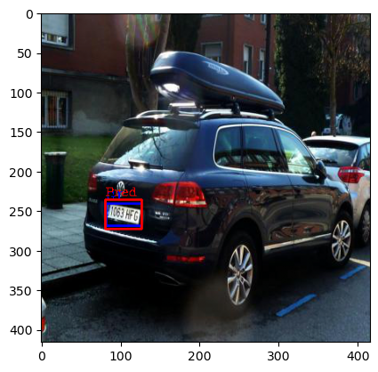

[figure not shown]

[figure not shown]

[figure not shown]

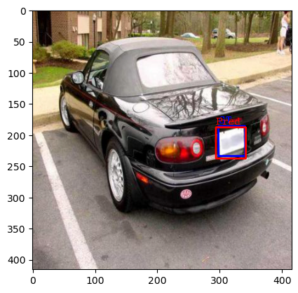

[figure not shown]

[figure not shown]

[figure not shown]

[figure not shown]

```python
import matplotlib.pyplot as plt

for i in range(NUM_IMG_TO_PLOT):
    plt.figure(i+1)
    plt.imshow(img_to_plot[i])
    plt.show()
```